# Take-home Exercise 6: Visualising and Analysing Community Network

This exercise is to find out the patterns in the social networks in the town, and describe ten significant patterns observed.

Huang Yaping https://www.linkedin.com/in/huang-yp/ (School of Computing and Information Systems)https://scis.smu.edu.sg/  
2022-06-06

### Install packages

```r
packages = c('igraph', 'tidygraph', 'ggraph', 'visNetwork', 'lubridate', 'clock','tidyverse', 'ggmap')
for(p in packages){
  if(!require(p, character.only = T)){
    install.packages(p)
  }
  library(p, character.only = T)
}
```

### Read small files

```r
participants <- read_csv("data/Participants.csv")
```

### Read big files; Data Wrangling to Aggregate the edges with weekdays, for August 2022, with weight > 3

```r
Edges <- read_csv("data/SocialNetwork.csv")
Edges_summary_weekdays <- Edges %>%
  mutate(date = ymd(timestamp)) %>%
  mutate(weekday = wday(date, label= TRUE, abbr = FALSE)) %>%
  mutate(month = month(date)) %>%
  filter(month == 8) %>%
  group_by(participantIdFrom, participantIdTo, weekday) %>%
  summarise(Weight = n()) %>%
  filter(participantIdFrom != participantIdTo) %>%
  filter(Weight>3) %>%
  ungroup
write_rds(Edges_summary_weekdays, "data/rds/Edges_summary_weekdays.rds")
```

### Data Wrangling to derive Edges and Nodes on Monday

```r
Edges_summary_weekdays <- read_rds("data/rds/Edges_summary_weekdays.rds")

Edges_Mon <- Edges_summary_weekdays %>%
  filter(weekday == "Monday")

write_rds(Edges_Mon, "data/rds/Edges_Mon.rds")
```

```r
Nodes_Mon <- data.frame(unique(unlist(Edges_Mon[1], Edges_Mon[2])))
colnames(Nodes_Mon)[1] <- "id"
```

```r
Nodes_Mon <- Nodes_Mon %>%
  left_join(participants, by = c("id" = "participantId"))
```

### Build graph model for Monday

graph_from_data_frame() of igraph is used to covert the nodes and edges data.frame into an igraph file format. as_tbl_graph() converts network data and objects to a tidygraph data model.

```r
graph_Mon <- graph_from_data_frame(Edges_Mon,
                                   vertices = Nodes_Mon) %>%
  as_tbl_graph()

graph_Mon
```

```
# A tbl_graph: 865 nodes and 7486 edges
#
# A directed simple graph with 14 components
#
# Node Data: 865 x 7 (active)
  name  householdSize haveKids   age educationLevel interestGroup
  <chr>         <dbl> <lgl>    <dbl> <chr>          <chr>
1 1                 3 TRUE        25 HighSchoolOrC~ B
2 2                 3 TRUE        35 HighSchoolOrC~ A
3 3                 3 TRUE        21 HighSchoolOrC~ I
4 4                 3 TRUE        43 Bachelors      H
5 5                 3 TRUE        32 HighSchoolOrC~ D
6 6                 3 TRUE        26 HighSchoolOrC~ I
# ... with 859 more rows, and 1 more variable: joviality <dbl>
#
# Edge Data: 7,486 x 4
   from    to weekday Weight
  <int> <int> <chr>    <int>
1     1   481 Monday       5
2     1   525 Monday       4
3     1   590 Monday       4
# ... with 7,483 more rows
```

### Construct a basic network graph On Mondays of August

To reveal the relationship of education vs connectedness

ggraph is an extension of the ggplot2 API tailored to graph visualizations and provides the same flexible approach to building up plots layer by layer.

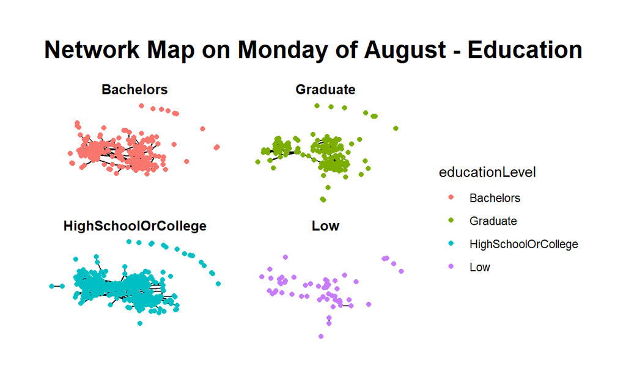

```r
set.seed(123)
ggraph(graph_Mon,
       layout = "fr")+
  geom_edge_link()+
  geom_node_point(aes(colour = educationLevel))+
  facet_nodes(~educationLevel)+
  theme_graph()+
  ggtitle("Network Map on Monday of August - Education")
```

Note: the above network shows that low education residents are sparsely connected.

### Construct a basic network graph On Mondays of August

To reveal the relationship of interest group vs connectedness

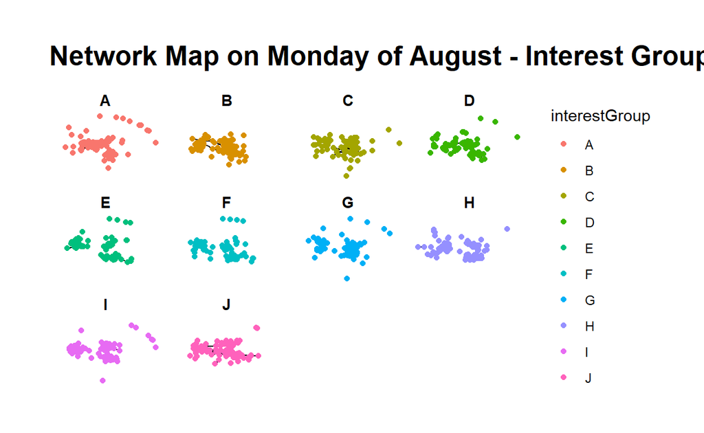

```r
set.seed(123)
ggraph(graph_Mon,
       layout = "fr")+
  geom_edge_link()+
  geom_node_point(aes(colour = interestGroup))+
  facet_nodes(~interestGroup)+
  theme_graph()+
  ggtitle("Network Map on Monday of August - Interest Group")
```

Observation: interest group B, C, D, and J shows activities on Monday.

### Data Wrangling to derive Edges and Nodes on Sunday

```r
Edges_Sun <- Edges_summary_weekdays %>%
  filter(weekday == "Sunday")
```

```r
Nodes_Sun <- data.frame(unique(unlist(Edges_Sun[1], Edges_Sun[2])))
colnames(Nodes_Sun)[1] <- "id"
```

```r
Nodes_Sun <- Nodes_Sun %>%
  left_join(participants, by = c("id" = "participantId"))
```

### Build graph model for Sunday

```r
graph_Sun <- graph_from_data_frame(Edges_Sun,
                                   vertices = Nodes_Sun) %>%
  as_tbl_graph()

graph_Sun
```

```
# A tbl_graph: 848 nodes and 5104 edges
#
# A directed simple graph with 15 components
#
# Node Data: 848 x 7 (active)
  name  householdSize haveKids   age educationLevel interestGroup
  <chr>         <dbl> <lgl>    <dbl> <chr>          <chr>
1 1                 3 TRUE        25 HighSchoolOrC~ B
2 2                 3 TRUE        35 HighSchoolOrC~ A
3 3                 3 TRUE        21 HighSchoolOrC~ I
4 4                 3 TRUE        43 Bachelors      H
5 5                 3 TRUE        32 HighSchoolOrC~ D
6 6                 3 TRUE        26 HighSchoolOrC~ I
# ... with 842 more rows, and 1 more variable: joviality <dbl>
#
# Edge Data: 5,104 x 4
   from    to weekday Weight
  <int> <int> <chr>    <int>
1     1   470 Sunday       4
2     1   642 Sunday       4
3     2    51 Sunday       4
# ... with 5,101 more rows
```

### Construct network graph On Sundays of August for people with and without kids

To find out how kids status impact how people are connnected on Sunday

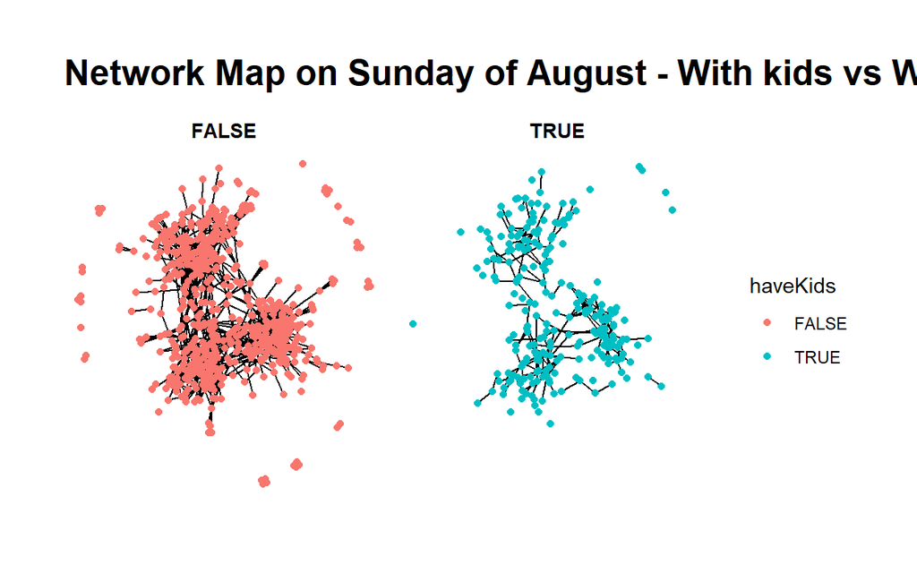

```r
set.seed(123)
ggraph(graph_Sun,
       layout = "fr")+
  geom_edge_link()+
  geom_node_point(aes(colour = haveKids))+
  facet_nodes(~haveKids)+
  theme_graph()+
  ggtitle("Network Map on Sunday of August - With kids vs Without Kids")
```

Observation: it can be seen that people with kids are less connected on Sunday.

### Construct an interest group network graph On Sundays of August

To find out how people in different interest groups are connected.

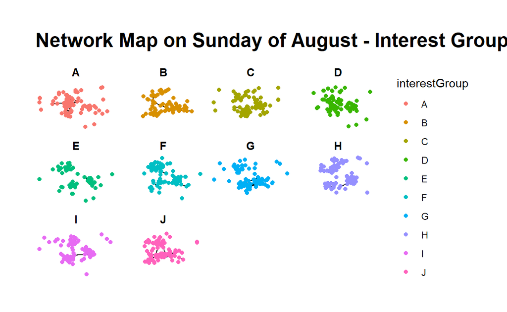

```r
set.seed(123)
ggraph(graph_Sun,
       layout = "fr")+
  geom_edge_link()+
  geom_node_point(aes(colour = interestGroup))+
  facet_nodes(~interestGroup)+
  theme_graph()+
  ggtitle("Network Map on Sunday of August - Interest Group")
```